# Using swedishbutterflies - tools from SeBMS

Markus Skyttner

2018-10-18

# Using “swedishbutterflies”

The R-package “swedishbutterflies” contains functions for retrieving data from SeBMS - the Swedish Butterfly Monitoring Scheme’s database. It can be used for accessing data, for generating static figures and for using an included Shiny proof-of-concept app.

## Retrieving off-line data

Some data is bundled into the package, for example:

```r
library(swedishbutterflies)

suppressPackageStartupMessages(library(purrr))
suppressPackageStartupMessages(library(dplyr))
suppressPackageStartupMessages(library(knitr))

# first few rows of precipitation 2015 data
sebms_data_precip_2015 %>%
head(5) %>%
kable()
```

| place | month | month.name | period | period.name | nb |
| --- | --- | --- | --- | --- | --- |
| Lund | 4 | april | 2 | 1961-1990 | 40 |
| Lund | 5 | maj | 2 | 1961-1990 | 45 |
| Lund | 6 | juni | 2 | 1961-1990 | 56 |
| Lund | 7 | juli | 2 | 1961-1990 | 70 |
| Lund | 8 | augusti | 2 | 1961-1990 | 65 |

```r
# same for temperature 2015 data
sebms_data_temp_2015 %>%
head(5) %>%
kable()
```

| place | month | month.name | period | period.name | temp |
| --- | --- | --- | --- | --- | --- |
| Lund | 4 | april | 2 | 1961-1990 | 6.0 |
| Lund | 5 | maj | 2 | 1961-1990 | 11.5 |
| Lund | 6 | juni | 2 | 1961-1990 | 15.4 |
| Lund | 7 | juli | 2 | 1961-1990 | 16.8 |
| Lund | 8 | augusti | 2 | 1961-1990 | 16.5 |

```r
# species counts
sebms_data_specieslist_cum %>%
head(5) %>%
kable()
```

| id | name | count |
| --- | --- | --- |
| 118 | Luktgräsfjäril | 10016 |
| 119 | Slåttergräsfjäril | 7774 |
| 17 | Mindre tåtelsmygare | 6478 |
| 28 | Kålfjäril | 6270 |
| 38 | Citronfjäril | 5710 |

```r
# species count histograms

sebms_data_species_histo %>%
head(5) %>%
kable()
```

| speuid | artnamn | situid | lokalnamn | vecka | sumval |
| --- | --- | --- | --- | --- | --- |
| 7 | Bredbrämad bastardsvärmare | 6 | Rökepipan | 31 | 1 |
| 7 | Bredbrämad bastardsvärmare | 23 | Enningervägen | 29 | 1 |
| 7 | Bredbrämad bastardsvärmare | 32 | Gamla Mörtforsvägen | 31 | 1 |
| 7 | Bredbrämad bastardsvärmare | 56 | Mallgårds Klint | 28 | 4 |
| 7 | Bredbrämad bastardsvärmare | 56 | Mallgårds Klint | 30 | 8 |

```r
sebms_data_species_per_site_sitetype %>%
head(5) %>%
kable()
```

| id | site | sitetype | species |
| --- | --- | --- | --- |
| 56 | Mallgårds Klint | T | 44 |
| 390 | Broknäs slinga 1, Bogesund | T | 42 |
| 603 | Horsakärr | T | 41 |
| 178 | Djäknabygd, Stenbrohult socken | T | 40 |
| 569 | L. Harsjön | T | 38 |

```r
# Naturum site locations
sebms_data_sites_naturum %>%
head(5) %>%
kable()
```

| Namn | Lat | Long |
| --- | --- | --- |
| Naturum Abisko | 68.35812 | 18.78484 |
| Naturum Blekinge | 56.19732 | 15.28689 |
| Naturum Dalarna | 60.78969 | 14.85332 |
| Naturum Falsterbo | 55.39293 | 12.85057 |
| Naturum Fjärås Bräcka | 57.44603 | 12.18500 |

## Retrieving on-line data

There are also functions for retrieving data from the database. These will fail if the db connection is not available.

Example usage:

```r
sebms_species_per_year() %>%
head(5) %>%
kable()
```

| id | name | count |
| --- | --- | --- |
| 119 | Slåttergräsfjäril | 339 |
| 131 | Ljungblåvinge/Hedblåvinge | 156 |
| 118 | Luktgräsfjäril | 155 |
| 30 | Rapsfjäril | 132 |
| 70 | Puktörneblåvinge | 123 |

```r
sebms_species_per_year_filtered() %>%
head(5) %>%
kable()
```

| id | name | count |
| --- | --- | --- |
| 119 | Slåttergräsfjäril | 339 |
| 131 | Ljungblåvinge/Hedblåvinge | 156 |
| 118 | Luktgräsfjäril | 155 |
| 30 | Rapsfjäril | 132 |
| 70 | Puktörneblåvinge | 123 |

```r
sebms_species_per_year_site_filtered() %>%
head(5) %>%
kable()
```

| id | site | sitetype | species |
| --- | --- | --- | --- |
| 63 | Trunelän, Maglehem | T | 41 |
| 603 | Horsakärr | T | 40 |
| 6 | Rökepipan | T | 32 |
| 587 | Björkafältet | T | 30 |
| 387 | Klören | T | 30 |

```r
sebms_species_per_year_site_counts_filtered() %>%
head(5) %>%
kable()
```

| id | site | sitetype | species | speciesno |
| --- | --- | --- | --- | --- |
| 6 | Rökepipan | T | 118 | 164 |
| 6 | Rökepipan | T | 119 | 162 |
| 6 | Rökepipan | T | 117 | 47 |
| 6 | Rökepipan | T | 103 | 28 |
| 6 | Rökepipan | T | 40 | 25 |

## Plotting figures

The figures can be included in an annual report.

Here is an example plotting a figure with temperature and precipitation data for 2015.

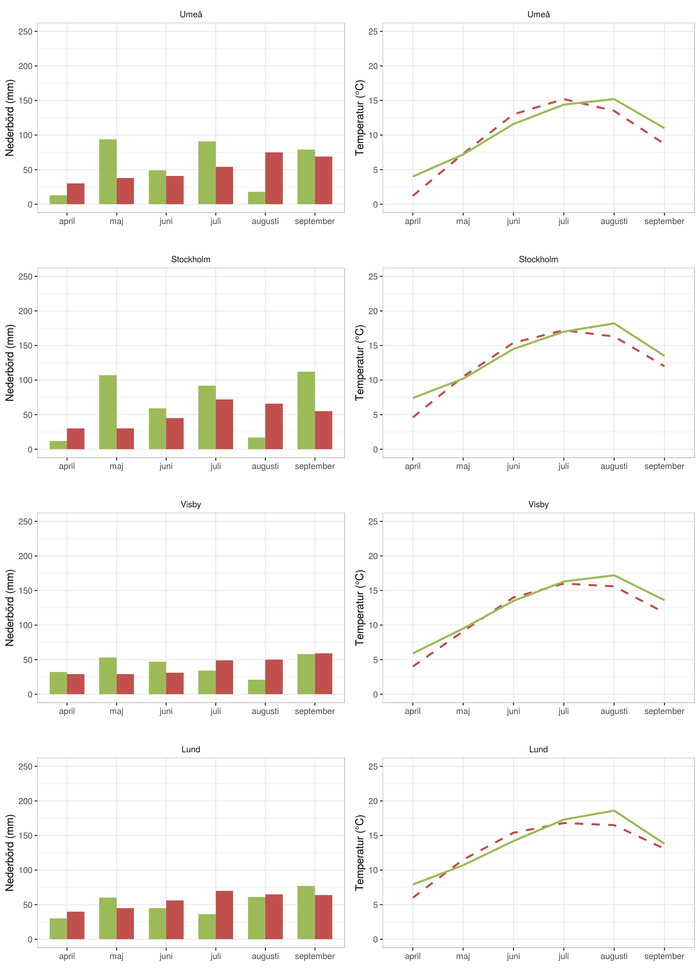

```r
library(magick)

sebms_precip_temp_2015_plot() %>%
  image_resize("700x")
```

The function above uses default bundled data. Custom data can also be used like in this minimal example:

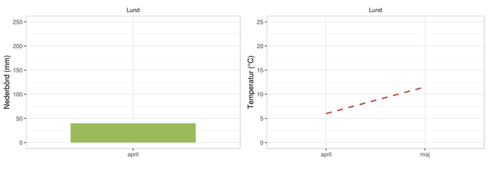

```r
test_precip <- tibble( # minimal example with 1 observation
  place = "Lund",
  month = 4, month.name = "april",
  period = 2, period.name = "1961-1990",
  nb = 40
)

test_temp <- tibble(  # minimal example with 2 observations
  place = "Lund",
  month = c(4, 5), month.name = c("april", "maj"),
  period = 2, period.name = "1961-1990",
  temp = c(6.00, 11.5)
)

sebms_precip_temp_plot(filter_cities = c("Lund"), test_precip, test_temp) %>%
  image_resize("700x")
```

Here is another example of the same plot, now using more data for two different cities; this example is intended to show usage of the arguments:

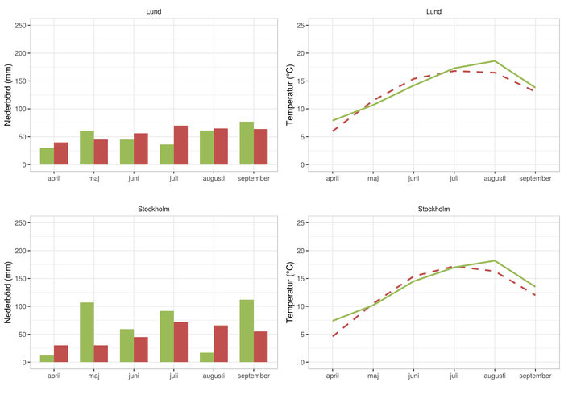

```r
test_precip2 <-
  sebms_data_precip_2015 %>%
  filter(place %in% c("Lund", "Stockholm"))

test_temp2 <-
  sebms_data_temp_2015 %>%
  filter(place %in% c("Lund", "Stockholm"))

plot <-
  sebms_precip_temp_plot(
    filter_cities = c("Lund", "Stockholm"),
    df_precip = test_precip2,
    df_temp = test_temp2
  )

plot %>% image_resize("700x")
```

Two plots for cumulative species counts can be generated like this:

```r
plots <- sebms_specieslist_cum_plots()

p1 <- plots$p1
p2 <- plots$p2
```

The first one looks like this:

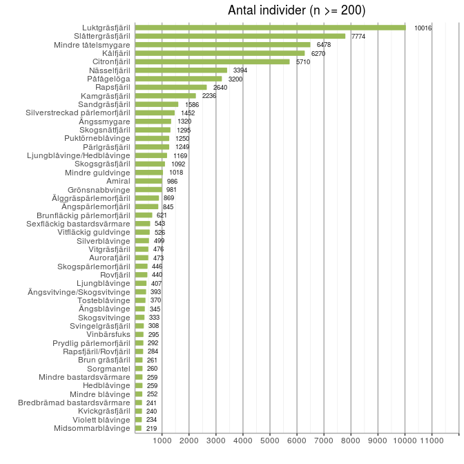

```r
p1
```

And the second one looks like this:

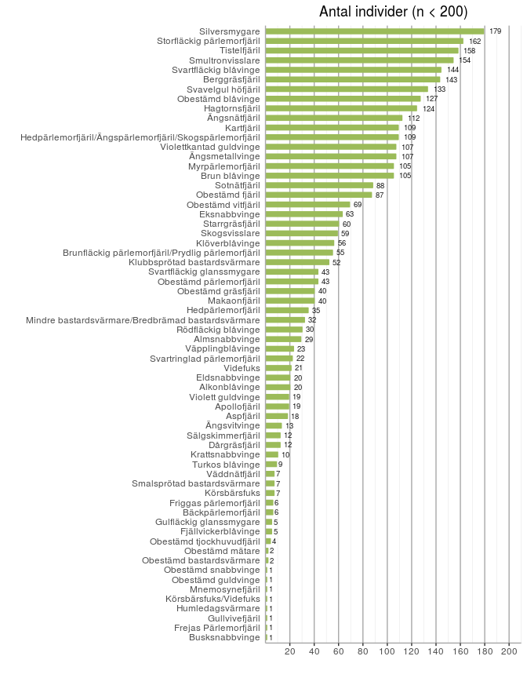

```r
p2
```

Static versions can also be saved given pixel-based width and height:

```r
p1 %>% sebms_ggsave(661, 812, filename = tempfile("specieslist-01", fileext = ".png"))
p2 %>% sebms_ggsave(666, 900, filename = tempfile("specieslist-02", fileext = ".png"))
```

Species count histograms:

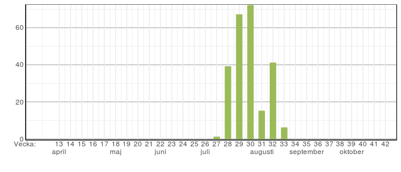

```r
sebms_species_histo_plot_orig()
```

A more technical variant of the same plot:

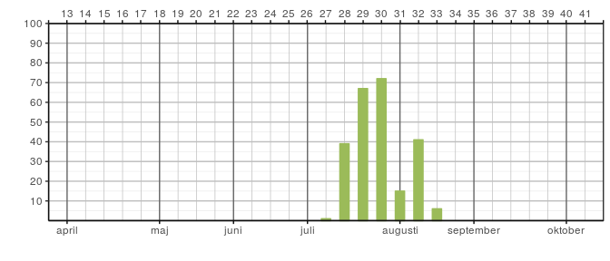

```r
sebms_species_histo_plot()
```

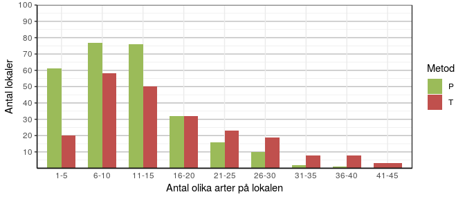

```r
sebms_species_per_site_sitetype_plot()
```

Sites per province and year:

```r
library(tibble)
library(DT)

sites <- sebms_data_sites_per_year_province

df <-
  t(sites) %>%
  as_tibble() %>%
  setNames(sites$province)

datatable(df, options = list(
  autoWidth = TRUE,
  scrollX = TRUE
))
```

|  | Sk | Bl | Ha | Sm | Öl | Go | Ög | Vg | Bo | Ds | Nä | Sö | Up | Vs | Vr | Dr | Gä | Hs | Me | Hr | Jä | Ån | Vb | Nb | Ly | Pi | Lu |
| --- | --- | --- | --- | --- | --- | --- | --- | --- | --- | --- | --- | --- | --- | --- | --- | --- | --- | --- | --- | --- | --- | --- | --- | --- | --- | --- | --- |
| 1 | 26 | 27 | 28 | 29 | 30 | 31 | 32 | 33 | 34 | 35 | 36 | 37 | 38 | 39 | 40 | 41 | 42 | 43 | 44 | 45 | 46 | 47 | 48 | 49 | 51 | 52 | 53 |
| 2 | Sk | Bl | Ha | Sm | Öl | Go | Ög | Vg | Bo | Ds | Nä | Sö | Up | Vs | Vr | Dr | Gä | Hs | Me | Hr | Jä | Ån | Vb | Nb | Ly | Pi | Lu |
| 3 | 46 | 25 | 4 | 18 | 2 | 14 | 11 | 27 | 6 | 2 | 9 | 13 | 22 | 47 | 2 | 6 | 4 | 1 | 1 | 1 | 4 | 1 | 4 | 5 |  | 1 | 1 |
| 4 | 63 | 3 | 7 | 6 | 1 | 18 | 9 | 19 | 9 | 3 | 6 | 12 | 18 | 6 | 22 | 4 |  |  |  |  | 6 |  | 4 | 5 | 1 |  | 1 |

Show some climate data for Naturum sites where butterflies might currently be observed:

```r
gogogo <-
  sebms_naturum_climate() %>%
  filter(is_gogogo) %>%
  dplyr::select(id, is_gogogo, t, ws, tcc_mean, pmean, date)

if (nrow(gogogo) == 0) {
  message("No butterflies expected, winter is coming?")
} else {
  gogogo %>% head(5) %>% kable
}
```

```
#> No butterflies expected, winter is coming?
```

## Spatial data and plots

There is also spatial data and functions for plotting included.

For example, data for sunhours is provided as a raster brick and can be plotted using ggplot or leaflet:

```r
# spatial data - a raster brick with sunhour layers
smhi_sunhours_rb
```

```
#> class       : RasterBrick
#> dimensions  : 93, 42, 3906, 13  (nrow, ncol, ncell, nlayers)
#> resolution  : 46366.31, 36797.25  (x, y)
#> extent      : 923200.7, 2870586, 7380058, 10802202  (xmin, xmax, ymin, ymax)
#> coord. ref. : +init=epsg:3857 +proj=merc +a=6378137 +b=6378137 +lat_ts=0.0 +lon_0=0.0 +x_0=0.0 +y_0=0 +k=1.0 +units=m +nadgrids=@null +no_defs
#> data source : in memory
#> names       :         ID, period_means, diff_latest,      X2007,      X2008,      X2009,      X2010,      X2011,      X2012,      X2013,      X2014,      X2015,      X2016
#> min values  :  9214.5000,     616.9944,   -311.9944,   545.3500,   748.5500,   624.9750,   411.8000,   502.5000,   510.5000,   655.6000,   845.5500,   562.3000,   543.7625
#> max values  : 42838.8000,    1537.7815,    301.5861,  1632.7000,  1659.4000,  1782.9600,  1517.3333,  1582.1000,  1485.7000,  1830.7000,  1651.4000,  1632.8500,  1706.3250
```

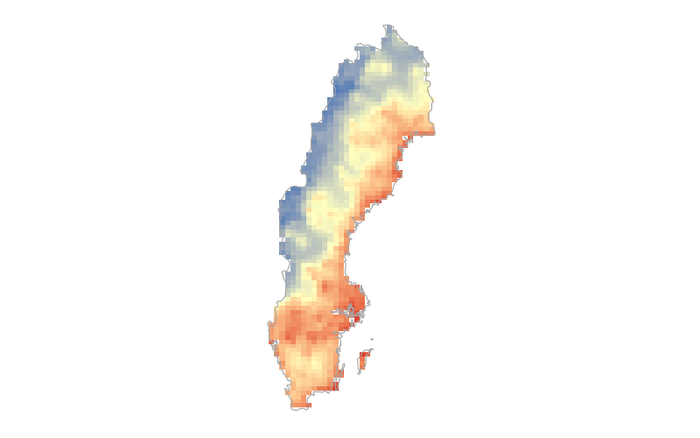

```r
sun <- smhi_sunhours_rb$period_means

# plot spatial data
fn_sun <- tempfile("plot-01", fileext = ".png")
sebms_sunhours_plot(rl = sun) %>%
  sebms_ggsave(filename = fn_sun)
img <- image_read(fn_sun)
unlink(fn_sun)
img %>% image_resize("700x")
```

```r
fn_sun <- tempfile("plot-02", fileext = ".png")
sebms_sunhours_plot(show_legend = TRUE) %>%
  sebms_ggsave(filename = fn_sun)
```

```
#> missing rl param, using default raster layer
```

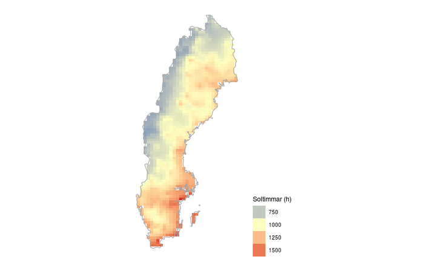

```r
img <- image_read(fn_sun)
unlink(fn_sun)
img %>% image_resize("700x")
```

The leaflet map can also be used with the SMHI sunhours data:

```r
library(leaflet)

  sebms_sunhours_leaflet(rl = smhi_sunhours_rb$diff_latest,
   options = leafletOptions(zoomControl = TRUE)) %>%
  addProviderTiles("Stamen.Watercolor",
    options = providerTileOptions(opacity = 0.25))
```

[interactive chart not shown]

Some spatial data for Swedish geography is included - polygons in `sebms_swe_borders` and a grid in `sebms_swe_grid`. These resources is used in a function that allows plotting of SeBMS locations/site data:

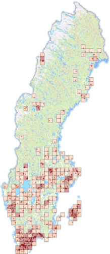

```r
library(sp)

occ_sp <- SpatialPoints(coords = sebms_data_sites,
  proj4string = CRS("+proj=tmerc +lat_0=0 +lon_0=15.80827777777778 +k=1 +x_0=1500000 +y_0=0 +ellps=bessel +units=m +no_defs"))

#df <- sebms_data_sites %>% dplyr::filter(`coords.x1` > 1380000)

# plot distribution of sites
sebms_species_site_plot(occ_sp)$plot %>% image_resize("x500")
```

The legend is available separately, if needed:

```r
# display a legend for the colors
sebms_species_site_plot(occ_sp)$legend %>%
  image_trim()
```

[output not shown]